# ACCESS Project (With reviewer’s responses addressed

Bill Liu

May 05, 2019

## Preparation

A select subset of SEER cancer data was exported from SEER*Stat. Along with related variables, these are imported into R and cleaned via code below. Variables deemed unusable are deleted. Cancer stage is grouped into I-IV, attributable death is recoded into binary, insurance status cleaned, and reporting type grouped recoded into factor variable.

Warning is supressed and output is excluded due to the amount of times whole tables are called in this preparation chunk.

```r
#Checking packages for missing data analysis
library(mice)
library(VIM)
library(lattice)

#Checking packages for Survival Analysis
library(readr) #for read txt file
library(survival) #for calculating KM values
library(survminer)#for pairwise diffs
```

```r
library(ggfortify) #for KM curves
library(readxl) # for reading in excel file
library(ggplot2) # for plotting KM curve
library(tidyverse) # for various packages
#Checking packages for Coxph Analysis
library(lmtest) #model comparison
library(stargazer) #model presentation
#Creating descriptives
library(tableone) #for descriptives
library(table1) #guess what there is another table1 package
#Getting data
ACCESS <- read.csv("SEER_BRCA_Access full data.csv")
str(ACCESS)

#Cleaning unneccessarily exported variables
ACCESS$SEER.registry <- NULL
ACCESS$County <- NULL
ACCESS$State.county <- NULL
str(ACCESS)

#Renaming variables
names(ACCESS)<-c("ID", "sex", "race", "birth_year", "diagnosis_age", "diagnosis_year", "poverty_perc", "education_perc", "site", "reporting", "survival", "stage", "insurance", "death_specific", "death_other")
str(ACCESS)

#Double checking the data exported from SEER*Stat are breast cancer patients
summary(ACCESS$site)

#Deleting this variable because it looked fine
ACCESS$site <- NULL

#Cleaning $stage
summary(ACCESS$stage)
ACCESS$stage_cleaned[
ACCESS$stage=="IA"|
ACCESS$stage=="IB"]<-0
ACCESS$stage_cleaned[
ACCESS$stage=="IIA"|
ACCESS$stage=="IIB"]<-1
ACCESS$stage_cleaned[
ACCESS$stage=="IIIA"|
ACCESS$stage=="IIIB"|
ACCESS$stage=="IIIC"|
ACCESS$stage=="IIINOS"]<-2
ACCESS$stage_cleaned[
ACCESS$stage=="IV"]<-3
ACCESS$stage_cleaned[
ACCESS$stage=="UNK Stage"]<-4
ACCESS$stage_cleaned<-factor(ACCESS$stage_cleaned,
levels = c(0,1,2,3,4),
labels = c("Stage 1", "Stage 2", "Stage 3", "Stage 4", "Stage Unknown"))
table(ACCESS$stage_cleaned)

#Cleaning $death_specific
summary(ACCESS$death_specific)
ACCESS$died[
ACCESS$death_specific=="Dead (attributable to this cancer dx)"]<-1
ACCESS$died[
ACCESS$death_specific=="Alive or dead of other cause"|
ACCESS$death_specific=="N/A not first tumor"]<-0
ACCESS$died<-factor(ACCESS$died,
levels = c(0, 1),
labels = c("Not breast cancer specific", "Died of breast cancer"))
table(ACCESS$died)

#Cleaning $insurance, totally copied these code word for word from HW9
ACCESS$insurance_cleaned[
ACCESS$insurance=="Insured"]<-0
ACCESS$insurance_cleaned[
ACCESS$insurance=="Insured/No specifics"]<-1
ACCESS$insurance_cleaned[
ACCESS$insurance=="Any Medicaid"]<-2
ACCESS$insurance_cleaned[
ACCESS$insurance=="Uninsured"]<-3
ACCESS$insurance_cleaned[
ACCESS$insurance=="Insurance status unknown"]<-4
ACCESS$insurance_cleaned<-factor(ACCESS$insurance_cleaned,
levels = c(0,1,2,3,4),
labels = c("Insured", "Insured/No specifics", "Any Medicaid", "Uninsured", "Unknown"))
table(ACCESS$insurance_cleaned)

#Cleaning $reporting
ACCESS$reporting_cleaned[
ACCESS$reporting=="Hospital inpatient/outpatient or clinic"]<-0
ACCESS$reporting_cleaned[
ACCESS$reporting=="Autopsy only"]<-1
ACCESS$reporting_cleaned[
ACCESS$reporting=="Death certificate only"]<-2
ACCESS$reporting_cleaned[
ACCESS$reporting=="Laboratory only (hospital or private)"]<-3
ACCESS$reporting_cleaned[
ACCESS$reporting=="Nursing/convalescent home/hospice"]<-4
ACCESS$reporting_cleaned[
ACCESS$reporting=="Other hospital outpatient unit or surgery center (2006+)"]<-5
ACCESS$reporting_cleaned[
ACCESS$reporting=="Physicians office/private medical practitioner (LMD)"]<-6
ACCESS$reporting_cleaned[
ACCESS$reporting=="Radiation treatment or medical oncology center (2006+)"]<-7
ACCESS$reporting_cleaned<-factor(ACCESS$reporting_cleaned,
levels = c(0,1,2,3,4,5,6,7),
labels = c("Hospital", "Autopsy", "Death certificate", "Laboratory", "Nursing home", "Surgery center", "Physicians office", "Oncology center"))
table(ACCESS$reporting_cleaned)

#Cleaning $survival
ACCESS$survival <- as.numeric(ACCESS$survival)
summary(ACCESS$survival)

#Cleaning $ID, because OCD
ACCESS$ID <- as.character(ACCESS$ID)
summary(ACCESS$ID)

#Cleaning $poverty_perc
ACCESS$poverty_perc <- as.numeric(ACCESS$poverty_perc)
summary(ACCESS$poverty_perc)

#Cleaning $education_perc
ACCESS$education_perc <- as.numeric(ACCESS$education_perc)
summary(ACCESS$education_perc)

#Checking variables that doesn't really need to be cleaned
summary(ACCESS$sex)
summary(ACCESS$race)
summary(ACCESS$birth_year)
summary(ACCESS$diagnosis_age)
summary(ACCESS$diagnosis_year)
```

## Missing data management

A separate dataset with just the used variables are created for clarity. This is done after I noticed that our main variables have no missing data. Surpirse! You get a kitty cat for that.

However cute, with the addition of control variables like insurance and stage of diagnosis, the missing data can amount to a significant number. The lack of missing data in our primary variables is possibly due to the fact that reporting source is how this dataset collected its data points, and survival is its primary end point.

Instead, in the next section, omission methods are used to treat the NAs. This has its limitations, as we are rounding down our sample size to a smaller population, potentially overlooking effects.

Still, I was curious so I did a marginsplot to see what no missing data pattern looks like anyways.

```
##  /\     /\
## {  `---'  }
## {  O   O  }
## ==>  V <==  No need for mice. This data set is completely observed.
##  \  \|/  /
##   `-----'
```

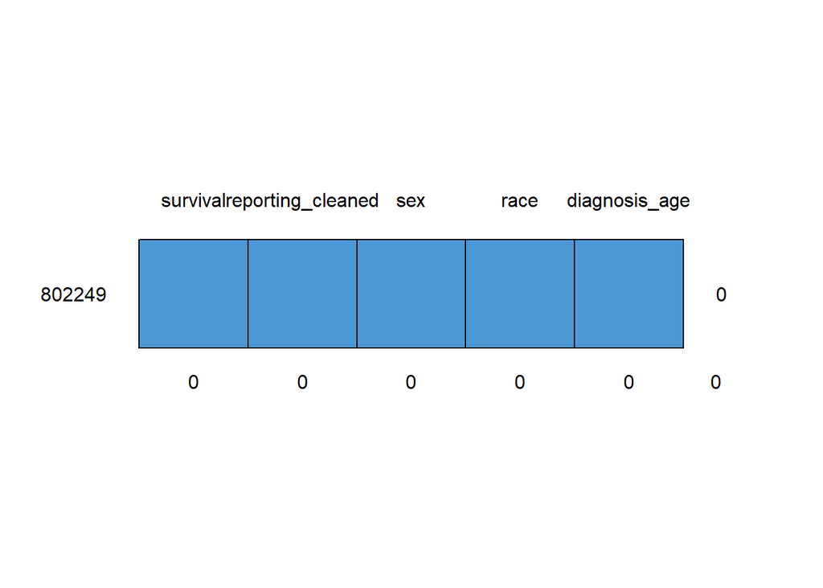

```
##        survival reporting_cleaned sex race diagnosis_age
## 802249        1                 1   1    1             1 0
##               0                 0   0    0             0 0
```

```r
#Creating dataset with specified variables to look at missing data
keeps<-c("survival", "reporting_cleaned", "sex", "race", "diagnosis_age") #keep only these variables
ACCESS_small<-ACCESS[keeps] #drops variables that are not in the keeps list

#Checking for missing data pattern
md.pattern(ACCESS_small)
```

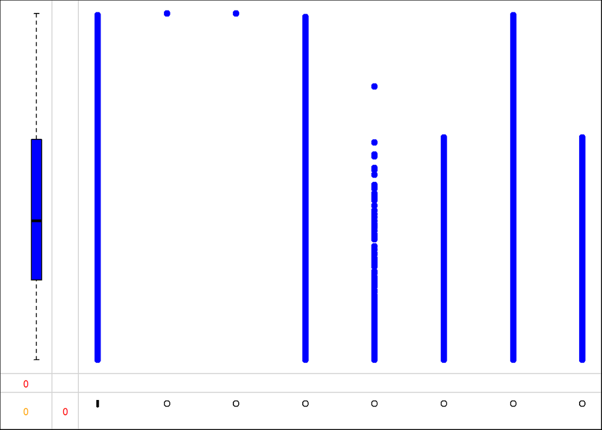

```r
#Oh look at that, an Easter egg. This is good news.

#Marginsplot, just for fun
marginplot(ACCESS_small[,c("reporting_cleaned","survival")], col=c("blue","red","orange"), cex=1,
cex.lab=1.3, cex.numbers=0.7, pch=19)
```

## CoxPHazard analysis

The reporting type variable is recoded to delete two categories “autopsy” and “death certificate”. The reason being that if breast cancer is reported at death, then all survival rates will be zero in those categoeis, therefore making our model invalid. In truth, checking for those categories returned a lot of zeros, as well as errors when running the ggsurvplot function. A new variable is created, and NAs are omitted. The data is checked again to ensure that previous encoding are properly coded, and no additional empty fields are generated through this process.

Three Cox Proportional Hazard regresion model are created. First, a univariate coxph model tests survival of reporting types. Second, a multivariate coxph model tests survival of reporting types with age adjusted. This model is used to graph survival plot. THird, another multivariate coxph model tests our association with the addition of control variables.

```r
#Cleaning $reporting
ACCESS$reporting_omit[
ACCESS$reporting=="Hospital inpatient/outpatient or clinic"]<-0
ACCESS$reporting_omit[
ACCESS$reporting=="Laboratory only (hospital or private)"]<-1
ACCESS$reporting_omit[
ACCESS$reporting=="Nursing/convalescent home/hospice"]<-2
ACCESS$reporting_omit[
ACCESS$reporting=="Other hospital outpatient unit or surgery center (2006+)"]<-3
ACCESS$reporting_omit[
ACCESS$reporting=="Physicians office/private medical practitioner (LMD)"]<-4
ACCESS$reporting_omit[
ACCESS$reporting=="Radiation treatment or medical oncology center (2006+)"]<-5
ACCESS$reporting_omit<-factor(ACCESS$reporting_omit,
levels = c(0,1,2,3,4,5),
labels = c("Hospital", "Laboratory", "Nursing home", "Surgery center", "Physicians office", "Oncology center"))
table(ACCESS$reporting_omit)
```

```
##
##          Hospital        Laboratory      Nursing home    Surgery center
##            767756              6160               475              9976
## Physicians office   Oncology center
##              9174              4932
```

```r
table(ACCESS$reporting_cleaned)
```

```
##
##          Hospital           Autopsy Death certificate        Laboratory
##            767756               172              3604              6160
##      Nursing home    Surgery center Physicians office   Oncology center
##               475              9976              9174              4932
```

```r
ACCESS_omit = na.omit(ACCESS)
head(ACCESS_omit)
```

```
##      ID    sex  race birth_year diagnosis_age diagnosis_year poverty_perc
## 7   357 Female White       1969            44           2013           69
## 8   390 Female White       1929            82           2012           24
## 10  560 Female Black       1925            85           2011          112
## 11  581 Female White       1941            71           2013           69
## 20 1505 Female White       1950            60           2010          112
## 28 2613 Female White       1959            52           2011           35
##    education_perc                               reporting survival
## 7             173 Hospital inpatient/outpatient or clinic       29
## 8             177 Hospital inpatient/outpatient or clinic       52
## 10            210 Hospital inpatient/outpatient or clinic       11
## 11            173 Hospital inpatient/outpatient or clinic       39
## 20            210 Hospital inpatient/outpatient or clinic       63
## 28             48 Hospital inpatient/outpatient or clinic       68
##        stage            insurance      death_specific         death_other
```

[output cut: 20 more lines]

```r
#Building a univariate cox proportional hazard model
survival_uni = coxph(Surv(survival, as.numeric(died)) ~ reporting_omit, data = ACCESS_omit, ties = "breslow")
summary(survival_uni)
```

```
## Call:
## coxph(formula = Surv(survival, as.numeric(died)) ~ reporting_omit,
##     data = ACCESS_omit, ties = "breslow")
##
##   n= 245927, number of events= 20976
##
##                                     coef exp(coef) se(coef)      z
## reporting_omitLaboratory         0.38991   1.47685  0.05916  6.590
## reporting_omitNursing home       3.41658  30.46494  0.08990 38.004
## reporting_omitSurgery center    -0.40105   0.66961  0.05200 -7.712
## reporting_omitPhysicians office  1.14634   3.14665  0.04383 26.155
## reporting_omitOncology center   -0.05100   0.95028  0.06563 -0.777
##                                 Pr(>|z|)
## reporting_omitLaboratory        4.39e-11 ***
## reporting_omitNursing home       < 2e-16 ***
## reporting_omitSurgery center    1.23e-14 ***
## reporting_omitPhysicians office  < 2e-16 ***
## reporting_omitOncology center      0.437
## ---
## Signif. codes:  0 '***' 0.001 '**' 0.01 '*' 0.05 '.' 0.1 ' ' 1
##
##                                 exp(coef) exp(-coef) lower .95 upper .95
## reporting_omitLaboratory           1.4768    0.67712    1.3151    1.6584
## reporting_omitNursing home        30.4649    0.03282   25.5433   36.3348
## reporting_omitSurgery center       0.6696    1.49340    0.6047    0.7415
## reporting_omitPhysicians office    3.1467    0.31780    2.8876    3.4289
## reporting_omitOncology center      0.9503    1.05232    0.8356    1.0807
##
## Concordance= 0.52  (se = 0.001 )
## Rsquare= 0.005   (max possible= 0.874 )
## Likelihood ratio test= 1210  on 5 df,   p=<2e-16
## Wald test            = 2213  on 5 df,   p=<2e-16
## Score (logrank) test = 4346  on 5 df,   p=<2e-16
```

```r
#Building a multivariate cox proportional hazard model
survival_multi = coxph(Surv(survival, as.numeric(died)) ~ reporting_omit + diagnosis_age, data = ACCESS_omit, ties = "breslow")
summary(survival_multi)
```

```
## Call:
## coxph(formula = Surv(survival, as.numeric(died)) ~ reporting_omit +
##     diagnosis_age, data = ACCESS_omit, ties = "breslow")
##
##   n= 245927, number of events= 20976
##
##                                       coef  exp(coef)   se(coef)      z
## reporting_omitLaboratory         0.3563170  1.4280601  0.0591842  6.020
## reporting_omitNursing home       3.2084864 24.7416095  0.0903475 35.513
## reporting_omitSurgery center    -0.4068411  0.6657500  0.0520011 -7.824
## reporting_omitPhysicians office  1.1004819  3.0056140  0.0438802 25.079
## reporting_omitOncology center   -0.0587409  0.9429510  0.0656275 -0.895
## diagnosis_age                    0.0121953  1.0122699  0.0005171 23.586
##                                 Pr(>|z|)
## reporting_omitLaboratory        1.74e-09 ***
## reporting_omitNursing home       < 2e-16 ***
## reporting_omitSurgery center    5.13e-15 ***
## reporting_omitPhysicians office  < 2e-16 ***
## reporting_omitOncology center      0.371
## diagnosis_age                    < 2e-16 ***
## ---
## Signif. codes:  0 '***' 0.001 '**' 0.01 '*' 0.05 '.' 0.1 ' ' 1
##
##                                 exp(coef) exp(-coef) lower .95 upper .95
## reporting_omitLaboratory           1.4281    0.70025    1.2717    1.6037
## reporting_omitNursing home        24.7416    0.04042   20.7264   29.5347
## reporting_omitSurgery center       0.6657    1.50207    0.6012    0.7372
## reporting_omitPhysicians office    3.0056    0.33271    2.7579    3.2755
## reporting_omitOncology center      0.9430    1.06050    0.8291    1.0724
## diagnosis_age                      1.0123    0.98788    1.0112    1.0133
##
## Concordance= 0.556  (se = 0.002 )
## Rsquare= 0.007   (max possible= 0.874 )
## Likelihood ratio test= 1768  on 6 df,   p=<2e-16
## Wald test            = 2775  on 6 df,   p=<2e-16
## Score (logrank) test = 4907  on 6 df,   p=<2e-16
```

```r
#Building a second multivariate cox proportional hazard model
survival_multi2 = coxph(Surv(survival, as.numeric(died)) ~ reporting_omit + diagnosis_age + sex + race + insurance_cleaned + stage_cleaned, data = ACCESS_omit, ties = "breslow")
summary(survival_multi2)
```

```
## Call:
## coxph(formula = Surv(survival, as.numeric(died)) ~ reporting_omit +
##     diagnosis_age + sex + race + insurance_cleaned + stage_cleaned,
##     data = ACCESS_omit, ties = "breslow")
##
##   n= 245927, number of events= 20976
##
##                                                                     coef
## reporting_omitLaboratory                                      -0.0174566
## reporting_omitNursing home                                     2.0650556
## reporting_omitSurgery center                                  -0.1841607
## reporting_omitPhysicians office                                0.7300702
## reporting_omitOncology center                                 -0.0942113
## diagnosis_age                                                  0.0211633
## sexMale                                                       -0.1054938
## raceOther (American Indian/AK Native, Asian/Pacific Islander) -0.5669863
## raceUnknown                                                   -2.1283240
## raceWhite                                                     -0.4143549
## insurance_cleanedInsured/No specifics                          0.1427895
## insurance_cleanedAny Medicaid                                  0.4787007
## insurance_cleanedUninsured                                     0.6606267
## insurance_cleanedUnknown                                       0.4211440
## stage_cleanedStage 2                                           1.4929268
## stage_cleanedStage 3                                           2.6981292
## stage_cleanedStage 4                                           4.1777466
## stage_cleanedStage Unknown                                     2.5329087
##                                                                exp(coef)
## reporting_omitLaboratory                                       0.9826949
## reporting_omitNursing home                                     7.8857367
## reporting_omitSurgery center                                   0.8318021
## reporting_omitPhysicians office                                2.0752263
## reporting_omitOncology center                                  0.9100904
## diagnosis_age                                                  1.0213888
## sexMale                                                        0.8998801
## raceOther (American Indian/AK Native, Asian/Pacific Islander)  0.5672323
## raceUnknown                                                    0.1190366
## raceWhite                                                      0.6607664
## insurance_cleanedInsured/No specifics                          1.1534870
## insurance_cleanedAny Medicaid                                  1.6139760
## insurance_cleanedUninsured                                     1.9360052
```

[output cut: 132 more lines]

```
## raceWhite                                                        0.6848
## insurance_cleanedInsured/No specifics                            1.2001
## insurance_cleanedAny Medicaid                                    1.6737
## insurance_cleanedUninsured                                       2.0808
## insurance_cleanedUnknown                                         1.6436
## stage_cleanedStage 2                                             4.6988
## stage_cleanedStage 3                                            15.6776
## stage_cleanedStage 4                                            68.7096
## stage_cleanedStage Unknown                                      13.5009
##
## Concordance= 0.858  (se = 0.001 )
## Rsquare= 0.159   (max possible= 0.874 )
## Likelihood ratio test= 42692  on 18 df,   p=<2e-16
## Wald test            = 41042  on 18 df,   p=<2e-16
## Score (logrank) test = 87548  on 18 df,   p=<2e-16
```

```r
#Create the new data for plotting adjusted survival curves for each treatment group using diagnosis_age set at the mean
reporting_mean = with(ACCESS_omit, data.frame(reporting_omit=c("Hospital", "Laboratory", "Nursing home", "Surgery center", "Physicians office", "Oncology center"), diagnosis_age=rep(mean(diagnosis_age, na.rm = T),6)))
reporting_mean
```

```
##      reporting_omit diagnosis_age
## 1          Hospital      61.83865
## 2        Laboratory      61.83865
## 3      Nursing home      61.83865
## 4    Surgery center      61.83865
## 5 Physicians office      61.83865
## 6   Oncology center      61.83865
```

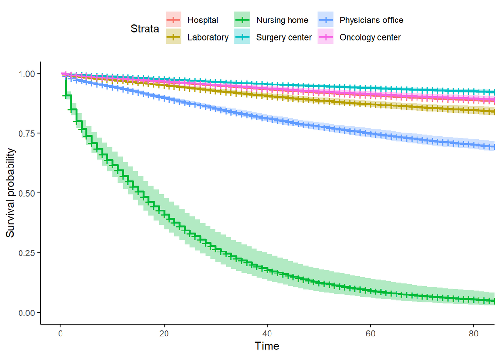

```r
ggsurvplot(survfit(survival_multi, newdata = reporting_mean), data = ACCESS_omit, conf.int = T,
           legend.labs = c("Hospital", "Laboratory", "Nursing home", "Surgery center", "Physicians office", "Oncology center"),
           ggtheme=theme_classic())
```

## Running some descriptives

Is it too late to tag it at the end? I did this because we modified variables in the last chunk and created new datasets.

```r
#Handy dandy package for descriptives.
table_one <- CreateTableOne(vars = c("sex", "race", "diagnosis_age", "insurance_cleaned", "stage_cleaned", "survival", "died"), strata = "reporting_omit", data = ACCESS_omit)
table_one
```

```
##                                                               Stratified by reporting_omit
##                                                                Hospital
##   n                                                            230949
##   sex = Male (%)                                                 1771 ( 0.8)
##   race (%)
##      Black                                                      25860 (11.2)
##      Other (American Indian/AK Native, Asian/Pacific Islander)  19198 ( 8.3)
##      Unknown                                                      988 ( 0.4)
##      White                                                     184903 (80.1)
##   diagnosis_age (mean (SD))                                     61.71 (13.73)
##   insurance_cleaned (%)
##      Insured                                                   165063 (71.5)
##      Insured/No specifics                                       30745 (13.3)
##      Any Medicaid                                               27291 (11.8)
##      Uninsured                                                   4407 ( 1.9)
##      Unknown                                                     3443 ( 1.5)
##   stage_cleaned (%)
##      Stage 1                                                   112927 (48.9)
##      Stage 2                                                    72259 (31.3)
##      Stage 3                                                    25462 (11.0)
##      Stage 4                                                    13282 ( 5.8)
##      Stage Unknown                                               7019 ( 3.0)
##   survival (mean (SD))                                          51.99 (19.84)
##   died = Died of breast cancer (%)                              19414 ( 8.4)
##                                                               Stratified by reporting_omit
##                                                                Laboratory
##   n                                                             2746
##   sex = Male (%)                                                  22 ( 0.8)
##   race (%)
##      Black                                                       208 ( 7.6)
##      Other (American Indian/AK Native, Asian/Pacific Islander)   544 (19.8)
##      Unknown                                                     278 (10.1)
##      White                                                      1716 (62.5)
##   diagnosis_age (mean (SD))                                    65.04 (14.71)
##   insurance_cleaned (%)
##      Insured                                                     850 (31.0)
##      Insured/No specifics                                        231 ( 8.4)
##      Any Medicaid                                                115 ( 4.2)
##      Uninsured                                                    33 ( 1.2)
##      Unknown                                                    1517 (55.2)
```

[output cut: 113 more lines]

```
##   diagnosis_age (mean (SD))                                    <0.001
##   insurance_cleaned (%)                                        <0.001
##      Insured
##      Insured/No specifics
##      Any Medicaid
##      Uninsured
##      Unknown
##   stage_cleaned (%)                                            <0.001
##      Stage 1
##      Stage 2
##      Stage 3
##      Stage 4
##      Stage Unknown
##   survival (mean (SD))                                         <0.001
##   died = Died of breast cancer (%)                             <0.001
```

## Response to reviewers

Also, done some code cleanup to the command to recode the variable “died” by including proper levels and labels. This means that an additional command have to be set in coxph models (as.numeric) to coerce it into a numerical variable.

RE: *For Table 1, I would suggest that you look at the characteristics in the left most column by whether they were alive or dead of breast cancer. So you will have 4 columns: 1) characteristics, 2) Overall, 3) Alive, and 4) Dead. I would also include the reporting source as a column 1 variable.*

```r
#New package actually. A new package is used (Table1) because I can't figure out how to display stratified and overall at the same time with the old package
table_two <- table1(~ sex + race + insurance_cleaned + stage_cleaned + reporting_omit + diagnosis_age + survival | died, data = ACCESS_omit)
table_two #Because it is not table one if there are two of them
```

|  | Not breast cancer specific (n=224951) | Died of breast cancer (n=20976) | Overall (n=245927) |
| --- | --- | --- | --- |
| sex |  |  |  |
| Female | 223254 (99.2%) | 20765 (99.0%) | 244019 (99.2%) |
| Male | 1697 (0.8%) | 211 (1.0%) | 1908 (0.8%) |
| race |  |  |  |
| Black | 23299 (10.4%) | 3908 (18.6%) | 27207 (11.1%) |
| Other (American Indian/AK Native, Asian/Pacific Islander) | 20116 (8.9%) | 1408 (6.7%) | 21524 (8.8%) |
| Unknown | 1546 (0.7%) | 29 (0.1%) | 1575 (0.6%) |
| White | 179990 (80.0%) | 15631 (74.5%) | 195621 (79.5%) |
| insurance_cleaned |  |  |  |
| Insured | 161671 (71.9%) | 11838 (56.4%) | 173509 (70.6%) |
| Insured/No specifics | 29819 (13.3%) | 3148 (15.0%) | 32967 (13.4%) |
| Any Medicaid | 24126 (10.7%) | 4128 (19.7%) | 28254 (11.5%) |
| Uninsured | 3840 (1.7%) | 810 (3.9%) | 4650 (1.9%) |
| Unknown | 5495 (2.4%) | 1052 (5.0%) | 6547 (2.7%) |
| stage_cleaned |  |  |  |
| Stage 1 | 118057 (52.5%) | 1797 (8.6%) | 119854 (48.7%) |
| Stage 2 | 71178 (31.6%) | 4761 (22.7%) | 75939 (30.9%) |
| Stage 3 | 21521 (9.6%) | 5117 (24.4%) | 26638 (10.8%) |
| Stage 4 | 6428 (2.9%) | 7546 (36.0%) | 13974 (5.7%) |
| Stage Unknown | 7767 (3.5%) | 1755 (8.4%) | 9522 (3.9%) |
| reporting_omit |  |  |  |
| Hospital | 211535 (94.0%) | 19414 (92.6%) | 230949 (93.9%) |
| Laboratory | 2456 (1.1%) | 290 (1.4%) | 2746 (1.1%) |
| Nursing home | 28 (0.0%) | 125 (0.6%) | 153 (0.1%) |
| Surgery center | 6303 (2.8%) | 377 (1.8%) | 6680 (2.7%) |
| Physicians office | 1993 (0.9%) | 535 (2.6%) | 2528 (1.0%) |
| Oncology center | 2636 (1.2%) | 235 (1.1%) | 2871 (1.2%) |
| diagnosis_age |  |  |  |
| Mean (SD) | 61.7 (13.6) | 63.5 (15.7) | 61.8 (13.8) |
| Median [Min, Max] | 62.0 [2.00, 108] | 63.0 [19.0, 104] | 62.0 [2.00, 108] |
| survival |  |  |  |
| Mean (SD) | 54.1 (18.5) | 26.9 (18.7) | 51.8 (20.0) |
| Median [Min, Max] | 55.0 [1.00, 84.0] | 25.0 [1.00, 84.0] | 53.0 [1.00, 84.0] |

RE: *Is there any prior literature on this topic? Typically, with respect to your main finding for nursing home residents with breast cancer?*

As discussed during the presentation, the association between nursing home residents with breast cancer and their survival is not a straightforward issue. There are multiple considerations. For one, those who are ill tend to register for nursing homes in order to receive round-the-clock care. They tend to be older, and nursing home is a typical choice for end-of-life care. Co-morbidities and old-age problems mediate the relationship between having reporting breast cancer at a nursing home and patients’ survival.

In a study on the functional status and survival of nursing home residents after breast cancer, the authors found that poorer pre-operative function is significantly associated with post-surgery mortality, as well as with post-operative functional decline.[citation 1] If we treat pre-operative function decline as an indicator or proxy of old age at nursing homes, the association found in our study is not independent. This suggest that there are unaccounted factors related to old age and nursing home that was not taken into account in our survival model. Especially in terms of end-of-life and survival, being a resident of nursing home is influenced by many associated factors. This is reinforced by literature, with authors pointing out that such functional decline can include decreased arm function due to surgery. The authors also highlighted that, poor social support for patients’ living at nursing homes are also found to be relevant in surgery survival and recovery, as well as the additional consideration of the high prevalence of cognitive impairment in the nursing home population.[citation 2]

In consideration of these factors associated with living at a nursing home, it seems that this report category is different in nature from the other reporting categories. Whereas nursing home captures a long range of a patient’s life (and its associated outcomes), other categories capture a relatively short duration (i.e. one visit). This can bias the observation, artificially inflating the hazard ratios. This is something to consider with further research, suggesting determining the detailed pathway might be a good path in clarifying the relationship found in this study.

1. Tang V, Zhao S, Boscardin J, Sudore R, Covinsky K, Walter L C, Esserman L, Mukhtar R, Finlayson E. Functional Status and Survival After Breast Cancer Surgery in Nursing Home Residents. JAMA Surg; 2018;153(12):1090-1096. Doi:10.1001/jamasurg.2018.2736
2. Goodwin J S, Satish S, Anderson E T, Nattinger A B, Freeman J L. Effect of Nurse Case Management on the Treatment of Older Women with Breast Cancer. Journal of the American Geriatrics Society; 2003;51(9):1252-1259. Doi:10.1046/j.1532-5415.2003.51409.x

RE: *Study population details? Who was excluded? Include diagnosis years in the information of who was included and which SEER database and age range was included.*

SEER 18 incidence data from 1975-2016 are used (Apr 15, 2019). It covers approximately 27.8% of the U.S. population based on estimates from the 2010 census. Although, according to SEER methodologies, different years of diagnosis are included for different registries in different areas. For example, Connecticut is included after 1975. Kentucky is included after 2000. However, our inclusion of the insurance recode variable limits all values to 2007+, as that is the earliest this variable is collected. SEER documentation does warn that insurance status might be modified by diagnosis age, since those who were 65+ were Medicare eligible despite labelling as uninsured, private, or unknown. However, this was not an issue in our analysis, as diagnosis age as low as 2, and as high as 108 years are adjusted and analyzed.

RE: *Define the cancer diagnosis reporting source - give us a feel for the variable and how it was measured. This information should be available from SEER.*

The variable reporting source is identifying the source documents used to abstract the case, as described in NAACCR Item #500. As discussed during the presentation, reporting source here does not represent the first diagnosis of disease, but the most complete source. Some categories are effective after 2996, but because of our insurance variable this does not pose an issue. This might confound our analysis and prevent us from using reporting source as a proxy for patients’ access to healthcare. However, in another way, this strengthens our ability to deduce access to care, as extensive screening might not be available to everyone. Those who choose to not receive additional care past the diagnosis event, or unable to receive care, are mitigated. Also, the exclusion of autopsy and death certification categories due to the nature of survival analysis also help circumvent this problem. This reduces the generalizability of our study, but help refine its comparative power.

RE: *How were other variables measured that were used in the analysis?*

Demographic data is collected, estimated, or produced by the U.S. Census Bureau’s Population Estimates Program, in collaboration with the National Center for Health Statistics, and with support from the NCI through an interagency agreement. Mortality data is collected and maintained by the National Center for Health Statistics. Cancer stage is derived following AJCC 7h edition guidelines, as well as incorporating ICD-10 codes. Insurance variable, as mentioned before, is derived from the NAACCR field.

RE: *Present confidence intervals instead of p-values in the results. I would like to see a table with the HRs and CIs and reference group. If you need an example, let me know, but if you search Pubmed for SEER survival, there will be numerous examples that you can look at.*

VARIABLE HAZARD RATIO (95% CI) P VALUE REPORTING  
HOSPITAL Reference - LABORATORY 0.98 (0.87, 1.11) 0.785 NURSING HOME 7.89 (6.56, 9.48) <0.001 SURGERY CENTER 0.83 (0.75, 0.92) <0.001 PHYSICIAN’S OFFICE 2.07 (1.88, 2.29) <0.001 ONCOLOGY CENTER 0.91 (0.80, 1.04) 0.152 DIAGNOSIS AGE 1.02 (1.02, 1.02) <0.001 SEX  
FEMALE Reference - MALE 0.90 (0.79, 1.03) 0.128 RACE  
BLACK Reference - OTHER (AMERICAN INDIAN/AK NATIVE, ASIAN/PACIFIC ISLANDER) 0.56 (0.53, 0.60) <0.001 UNKNOWN 0.12 (0.08, 0.17) <0.001 WHITE 0.66 (0.64, 0.68) <0.001 INSURANCE  
INSURED Reference - INSURED/NO SPECIFICS 1.15 (1.11, 1.20) <0.001 ANY MEDICAID 1.61 (1.56, 1.67) <0.001 UNINSURED 1.94 (1.80, 2.08) <0.001 UNKNOWN 1.52 (1.41, 1.64) <0.001 STAGE OF DIAGNOSIS  
STAGE 1 Reference - STAGE 2 4.45 (4.21, 4.70) <0.001 STAGE 3 14.85 (14.07, 15.68) <0.001 STAGE 4 65.22 (61.91, 68.71) <0.001 STAGE UNKNOWN 12.59 (11.74, 13.50) <0.001